# DATA605 Homework 15

Henry Otuadinma

08/12/2019

#### 1.) Find the equation of the regression line for the given points. Round any final values to the nearest hundredth, if necessary. ( 5.6, 8.8 ), ( 6.3, 12.4 ), ( 7, 14.8 ), ( 7.7, 18.2 ), ( 8.4, 20.8 )

solution

```r
x <- c(5.6, 8.8, 6.3, 12.4, 7, 14.8, 7.7, 18.2, 8.4, 20.8)

m <- matrix(x, ncol=2, byrow = T)
```

```r
df <- data.frame(m)

(lm_df <- lm(df$X2 ~., df))
```

```
##
## Call:
## lm(formula = df$X2 ~ ., data = df)
##
## Coefficients:
## (Intercept)           X1
##     -14.800        4.257
```

```r
summary(lm_df)
```

```
##
## Call:
## lm(formula = df$X2 ~ ., data = df)
##
## Residuals:
##     1     2     3     4     5
## -0.24  0.38 -0.20  0.22 -0.16
##
## Coefficients:
##             Estimate Std. Error t value Pr(>|t|)
## (Intercept) -14.8000     1.0365  -14.28 0.000744 ***
## X1            4.2571     0.1466   29.04 8.97e-05 ***
## ---
## Signif. codes:  0 '***' 0.001 '**' 0.01 '*' 0.05 '.' 0.1 ' ' 1
##
## Residual standard error: 0.3246 on 3 degrees of freedom
## Multiple R-squared:  0.9965, Adjusted R-squared:  0.9953
## F-statistic: 843.1 on 1 and 3 DF,  p-value: 8.971e-05
```

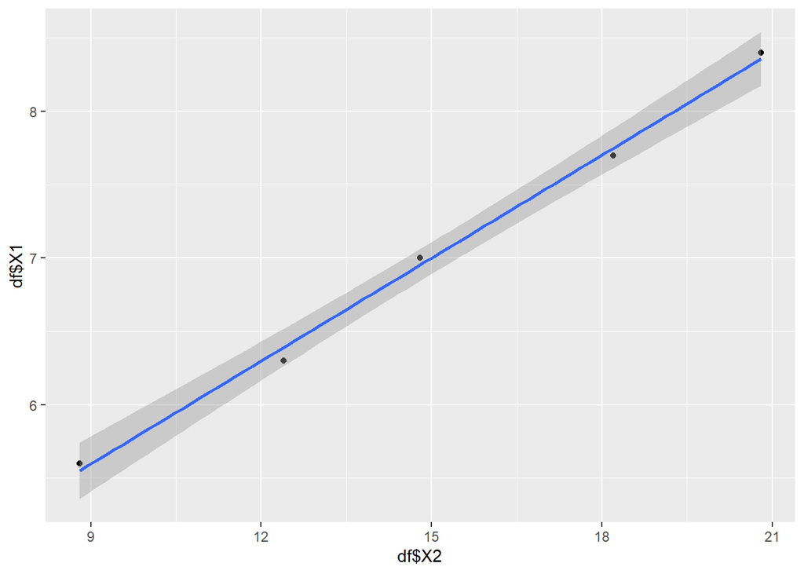

```r
ggplot(lm_df, aes(df$X2, df$X1)) + geom_point() + stat_smooth(method="lm")
```

The equation is:

$y = 4.2571x − 14.800$

#### 2.) Find all local maxima, local minima, and saddle points for the function given below. Write your answer(s) in the form ( x, y, z ). Separate multiple points with a comma.

$f(x, y) = 24x - 6xy^2 - 8y^3$

solution:

$\frac{df}{dx} = 24 - 6y^2$

$\frac{df}{dy} = - 12xy - 24y^2$

$\frac{df}{dx} = 24 - 6y^2 = 0 => 4 - y^2 = 0$

$\frac{df}{dx} = -12xy - 24y^2 = 0 => -xy - 2y^2 = 0$

$for(4, -2)f(x, y) = 24 * 4 - 6 * 4 * (-2)^2 - 8(-2)^3 = 64$

#### OR

```r
xf = function(x,y){
  f = 24*x - 6*x*y^2 - 8*y^3
  return(c(x,y,f))
}
```

```r
print(rbind(xf(-4,2),xf(4,-2)))
```

```
##      [,1] [,2] [,3]
## [1,]   -4    2  -64
## [2,]    4   -2   64
```

#### 3.) A grocery store sells two brands of a product, the “house” brand and a “name” brand. The manager estimates that if she sells the “house” brand for x dollars and the “name” brand for y dollars, she will be able to sell $81 - 21x + 17y$ units of the “house” brand and $40 + 11x - 23y$ units of the “name” brand.

#### Step 1. Find the revenue function R ( x, y ).

#### Step 2. What is the revenue if she sells the “house” brand for $2.30 and the “name” brand for $4.10?

Solution:

$R(x,y)=x(81−21x+17y)+y(40+11x−23y)$

$R(x,y)= −21x^2 + 81x + 28xy + 40y −23y^2$

```r
x <- 2.3
y <- 4.1
print(-21 * x^2 + 81 * x + 28 * x * y + 40 * y - 23 * y^2)
```

```
## [1] 116.62
```

#### 4. A company has a plant in Los Angeles and a plant in Denver. The firm is committed to produce a total of 96 units of a product each week. The total weekly cost is given by C(x, y) = 1/6 x2 + 1/6 y2 + 7x + 25y + 700, where x is the number of units produced in Los Angeles and y is the number of units produced in Denver. How many units should be produced in each plant to minimize the total weekly cost?

solution:

$x + y = 96$ since $y = 96 − x$ =>

we have $x = 75 => y = 21$

#### 5.) Evaluate the double integral on the given region.

$\int{\int{e^{8x + 3y}dA}}; R:2\le x\le 4 \text{ and $2\le y\le 4$}$

Write your answer in exact form without decimals.

solution:

with R =>

```r
1/24*((exp(32)+exp(16))*(exp(12) - exp(6)))
```

```
## [1] 5.341561e+17
```

##### OR

$\int_2^4{\int_2^4{e^{8xe^{3y}}dxdy}}$

$\int{e^{8x}dx}*\int{e^{3y}}dy$

$=\frac{1}{8}e^{8x}|^4_2 * \frac{1}{3}e^{3y}|_2^4$

$=\frac{1}{24}e^{8x}|^4_2 * e^{3y}|^4_2$

$=\frac{1}{24}(e^{32}-e^{16})(e^{12}-e^6)$

=>$A = 534, 156, 100, 000, 000, 000$